# case_agibank

Marina de Freitas Lima

### Carregamento das bibliotecas

```r
library(tidyverse)
```

```r
library(ggplot2)
library(cluster)
library(factoextra)
#install.packages("arules")
library(arules)
```

## Carregamento dos dados

```r
itemtransacao = read_csv("itemtransacao.csv")
itens = read_csv("itens.csv")
transacoes = read_csv("transacoes.csv")
print(names(itemtransacao))
```

```
## [1] "IDTransação" "item"
```

```r
print(names(itens))
```

```
## [1] "codItem"   "descrição" "marca"     "tipo"
```

```r
print(names(transacoes))
```

```
## [1] "IDTransação"    "valorTotal"     "tipo pagamento"
```

### Breve espiada nos dados

```r
for(col in names(itemtransacao) ){
  print(col)
  print(nrow(unique(itemtransacao[col])))
  print(unique(itemtransacao[col]))
}
```

```
## [1] "IDTransação"
## [1] 27
## # A tibble: 27 × 1
##    IDTransação
##          <dbl>
##  1          27
##  2          28
##  3          29
##  4          30
##  5          31
##  6          32
##  7          33
##  8          34
##  9          35
## 10           1
```

[output cut: 16 more lines]

```r
for(col in names(itens) ){
  print(col)
  print(nrow(unique(itens[col])))
  print(unique(itens[col]))
}
```

```
## [1] "codItem"
## [1] 10
## # A tibble: 10 × 1
##    codItem
##      <dbl>
##  1       1
##  2       2
##  3       3
##  4       4
##  5       5
##  6       6
##  7       7
##  8      12
##  9      11
## 10      10
```

[output cut: 35 more lines]

```r
for(col in names(transacoes) ){
  print(col)
  print(nrow(unique(transacoes[col])))
  print(unique(transacoes[col]))
}
```

```
## [1] "IDTransação"
## [1] 34
## # A tibble: 34 × 1
##    IDTransação
##          <dbl>
##  1           1
##  2           2
##  3           3
##  4           4
##  5           5
##  6           6
##  7           7
##  8           8
##  9           9
## 10          10
```

[output cut: 27 more lines]

```r
itens$tipo <- gsub("refirgerante", "refrigerante", itens$tipo)
itens$marca <- gsub("limão", "limao", itens$marca)
```

### Transformação dados

```r
dados = itemtransacao %>%
group_by(IDTransação,item) %>%
summarise(qtd_itens = n()) %>%
left_join(itens, by = c("item"="codItem")) %>%
select("IDTransação","descrição","qtd_itens")%>%
pivot_wider(names_from = "descrição", values_from = "qtd_itens")
dados[is.na(dados)] <- 0
```

```r
dados_itemtransacao = dados %>% left_join(transacoes, by = "IDTransação" )
```

```r
dados_marca =  itemtransacao %>%
  left_join(itens, by = c("item"="codItem")) %>%
  select("IDTransação","tipo","marca")%>%
  pivot_wider(names_from = "tipo", values_from = "marca")
dados_tipo =  itemtransacao %>%
  left_join(itens, by = c("item"="codItem")) %>%
  select("IDTransação","tipo","descrição")%>%
  pivot_wider(names_from = "tipo", values_from = "descrição")
dados_marca_desc =  itemtransacao %>%
  left_join(itens, by = c("item"="codItem")) %>%
  select("IDTransação","marca","descrição")%>%
  pivot_wider(names_from = "marca", values_from = "descrição")
```

## Análise exploratória

### Hipóteses

- Quem compra um sabão não compra outro na mesma compra?

```r
dados_tipo$qtd_sabao = unlist(lapply(dados_tipo$`sabao em po`,length))
dados_tipo %>% group_by(qtd_sabao) %>% summarise(ocorrencias = n(), percentagem = round(n()/nrow(dados_tipo)*100,2))
```

```
## # A tibble: 3 × 3
##   qtd_sabao ocorrencias percentagem
##       <int>       <int>       <dbl>
## 1         0           7       25.9
## 2         1          18       66.7
## 3         2           2        7.41
```

Apesar de não acorrer muito, apenas 7% das compras, mas clientes podem comprar mais de um sabão na mesma compra.

- Quem compra um tipo de limão ou banana não compra outro? Exemplo: se comprou o Taiti não compra o Siciliano.

```r
dados_marca_desc$qtd_limao = unlist(lapply(dados_marca_desc$limao,length))
dados_marca_desc %>% group_by(qtd_limao) %>% summarise(ocorrencias = n())
```

```
## # A tibble: 2 × 2
##   qtd_limao ocorrencias
##       <int>       <int>
## 1         0           9
## 2         1          18
```

Todos clientes que compraram limão, compraram apenas de um tipo.

```r
dados_marca_desc$qtd_banana = unlist(lapply(dados_marca_desc$banana,length))
dados_marca_desc %>% group_by(qtd_banana) %>% summarise(ocorrencias = n())
```

```
## # A tibble: 2 × 2
##   qtd_banana ocorrencias
##        <int>       <int>
## 1          0           5
## 2          1          22
```

Todos clientes que compraram banana, compraram apenas de um tipo.

- Quem compra fruta, compra apenas um tipo ou mais?

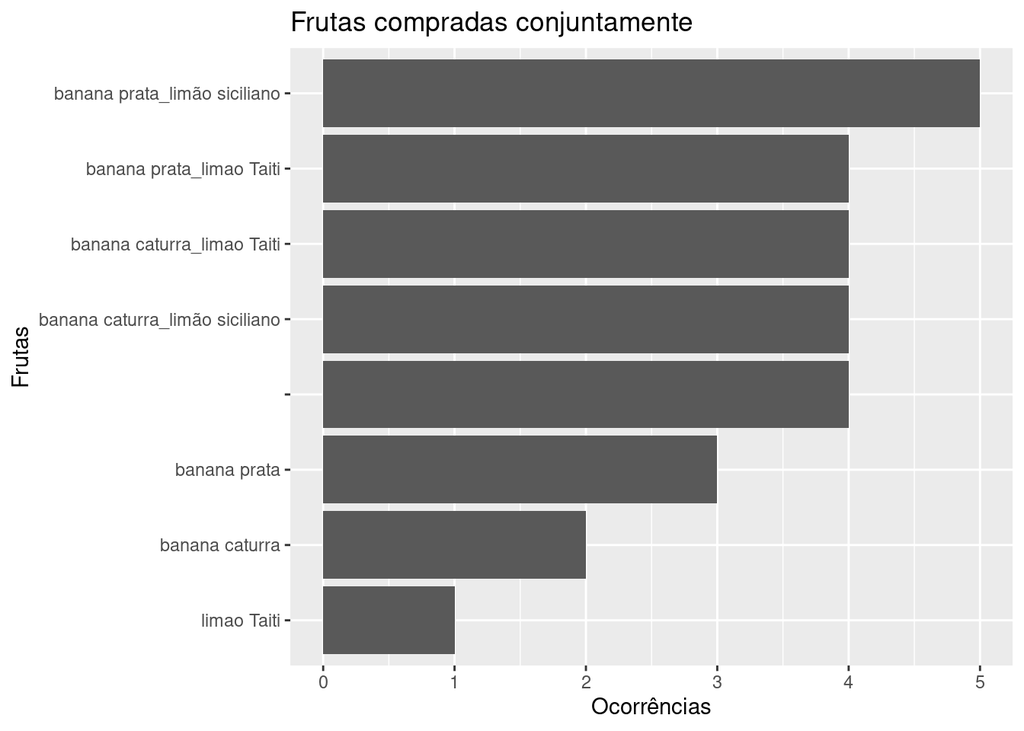

```r
dados_tipo$frutas_compradas = unlist(lapply(dados_tipo$fruta,function(x) paste(unlist(x), collapse = "_")))
hist_frutas = dados_tipo %>% group_by(frutas_compradas) %>% summarise(ocorrencias = n())

ggplot(hist_frutas, aes(x=reorder(frutas_compradas, ocorrencias),
                                 y = ocorrencias)) +
       geom_col() + coord_flip() + labs( x="Frutas", y="Ocorrências",title='Frutas compradas conjuntamente')
```

É mais comum comprarem limão e banana, do que só limão ou só banana, independente do tipo da fruta.

- Quem compra um tipo de refrigerante não compra outro? Exemplo: se comprou a coca light não comprará a coca normal.

```r
dados_tipo$qtd_refri = unlist(lapply(dados_tipo$refrigerante,length))
dados_tipo %>% group_by(qtd_refri) %>% summarise(ocorrencias = n())
```

```
## # A tibble: 3 × 2
##   qtd_refri ocorrencias
##       <int>       <int>
## 1         0           5
## 2         1          21
## 3         2           1
```

É mais comum comprarem apenas um refrigerante por compra.

- Quais são os produtos mais comprados jutos.

## Clusterização

```r
# Padronizar os dados
dados_scaled <- dados %>%  select(-"IDTransação") %>% scale()
```

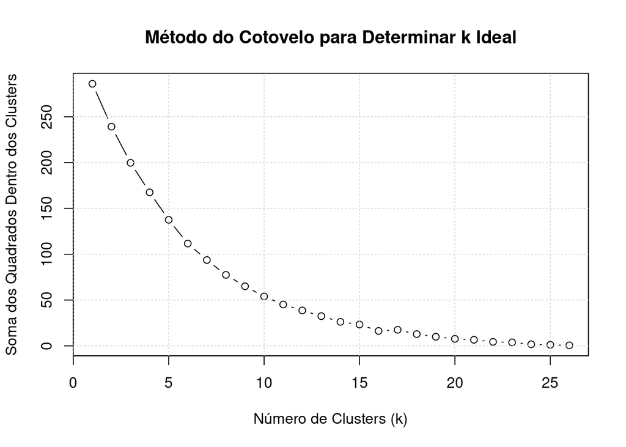

```r
# Calcular a soma dos quadrados dentro dos clusters (WSS - Within-Cluster Sum of Squares) para diferentes valores de k
wss <- c()
for(k in 1:26) {
    km <- kmeans(dados_scaled, centers = k, nstart = 25)
    wss <- c(wss, km$tot.withinss)
}

# Criar o gráfico de cotovelo
plot(1:26, wss, type = "b",
     xlab = "Número de Clusters (k)",
     ylab = "Soma dos Quadrados Dentro dos Clusters",
     main = "Método do Cotovelo para Determinar k Ideal")

grid()
```

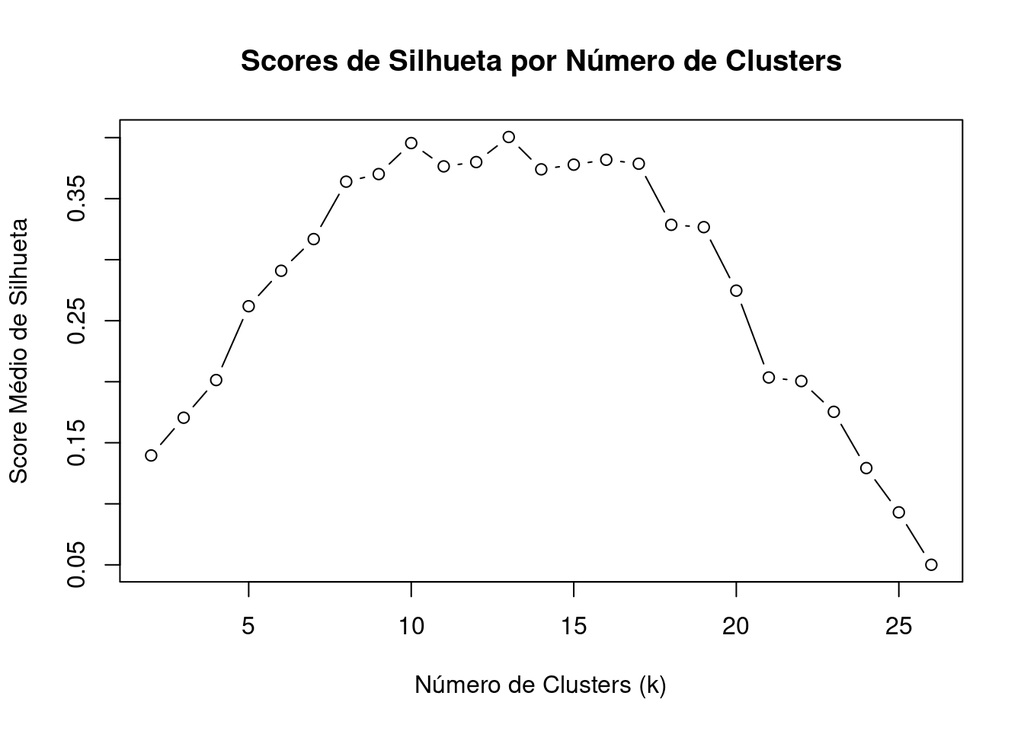

```r
# Para encontrar o número ideal de clusters usando silhueta
silhouette_scores <- c()
for(k in 2:26) {
    km <- kmeans(dados_scaled, centers = k, nstart = 25)
    sil_score <- mean(silhouette(km$cluster, dist(dados_scaled))[,3])
    silhouette_scores <- c(silhouette_scores, sil_score)
}

# Plotar scores de silhueta para diferentes valores de k
plot(2:26, silhouette_scores, type = "b",
     xlab = "Número de Clusters (k)",
     ylab = "Score Médio de Silhueta",
     main = "Scores de Silhueta por Número de Clusters")
```

```r
# Método K-means

k=10

kmeans_result <- kmeans(dados_scaled, centers = k, nstart = 25)

dados$cluster_kmeans <- unlist(kmeans_result['cluster'])

# Calcular e plotar a silhueta para K-means

# Calcular a silhueta
sil <- silhouette(kmeans_result$cluster, dist(dados_scaled))

print(mean(sil[,3]))
```

```
## [1] 0.3955316
```

```r
qtd_trans_cluster = aggregate(. ~ cluster_kmeans, data = dados, n_distinct) %>% subset(select = c(cluster_kmeans,IDTransação))

result_cluster = aggregate(. ~ cluster_kmeans, data = dados, sum) %>% subset(select = c(-IDTransação)) %>% left_join(qtd_trans_cluster, by=c("cluster_kmeans"))
result_cluster
```

```
##    cluster_kmeans banana prata limão siciliano ariel total banana caturra coca
## 1               1            0               0           1              2    0
## 2               2            0               4           0              4    0
## 3               3            3               1           3              0    0
## 4               4            2               2           0              0    0
## 5               5            0               0           2              2    1
## 6               6            2               0           1              0    0
## 7               7            2               0           0              0    0
## 8               8            0               0           1              2    2
## 9               9            3               2           0              0    2
## 10             10            0               0           0              0    0
##    limao Taiti coca light omo progress coca lemon light omo collors IDTransação
## 1            2          0            0                2           0           2
## 2            0          4            2                0           0           4
## 3            2          1            0                0           0           3
## 4            0          0            0                2           2           2
## 5            0          0            0                0           0           3
## 6            0          4            0                0           4           4
## 7            2          2            2                0           0           2
## 8            2          0            0                0           2           2
## 9            0          0            0                0           0           3
## 10           1          1            2                2           0           2
```

**Observações:**

Todos que compraram algum omo (progress ou colors) também compraram alguma coca (normal, light ou lemon light). Quem compra Ariel, geralmente compra algum tipo de banana.

# Algoritmo Apriori

## Transformação dados para Apriori

```r
dados_apriori_aux <- itemtransacao %>%
left_join(itens, by = c("item"="codItem"))
dados_apriori_aux$IDTransação =  factor(dados_apriori_aux$IDTransação)
dados_apriori_split = split(dados_apriori_aux$descrição,
                  dados_apriori_aux$IDTransação)

dados_apriori = as(dados_apriori_split,"transactions")
inspect(dados_apriori)
```

```
##      items               transactionID
## [1]  {ariel total,
##       banana prata,
##       limão siciliano}              1
## [2]  {ariel total}                  2
## [3]  {ariel total,
##       banana caturra}               3
## [4]  {banana caturra,
##       coca}                         5
## [5]  {ariel total,
##       banana prata,
##       limao Taiti}                  6
## [6]  {ariel total,
##       banana prata,
##       coca light,
##       limao Taiti}                  14
## [7]  {banana prata,
##       coca light,
##       limao Taiti,
##       omo progress}                 15
## [8]  {banana caturra,
##       coca light,
##       limão siciliano}              16
## [9]  {banana caturra,
##       coca light,
##       limão siciliano,
##       omo progress}                 17
## [10] {banana prata,
##       coca,
##       limão siciliano}              18
## [11] {banana prata,
##       coca lemon light,
##       limão siciliano,
##       omo collors}                  19
## [12] {ariel total,
##       banana caturra,
##       coca lemon light,
##       limao Taiti}                  20
## [13] {ariel total,
##       banana caturra,
```

[output cut: 31 more lines]

```
##       limao Taiti}                  31
## [24] {banana caturra,
##       coca,
##       limao Taiti,
##       omo collors}                  32
## [25] {banana prata,
##       coca light,
##       omo collors}                  33
## [26] {ariel total,
##       coca light,
##       omo collors}                  34
## [27] {coca lemon light,
##       coca light,
##       limao Taiti,
##       omo progress}                 35
```

```r
summary(dados_apriori)
```

```
## transactions as itemMatrix in sparse format with
##  27 rows (elements/itemsets/transactions) and
##  10 columns (items) and a density of 0.3148148
##
## most frequent items:
##    banana prata      coca light  banana caturra limão siciliano     limao Taiti
##              12              12              10               9               9
##         (Other)
##              33
##
## element (itemset/transaction) length distribution:
## sizes
##  1  2  3  4  5
##  2  4 10 10  1
##
##    Min. 1st Qu.  Median    Mean 3rd Qu.    Max.
##   1.000   3.000   3.000   3.148   4.000   5.000
##
## includes extended item information - examples:
##           labels
## 1    ariel total
## 2 banana caturra
## 3   banana prata
##
## includes extended transaction information - examples:
##   transactionID
## 1             1
## 2             2
## 3             3
```

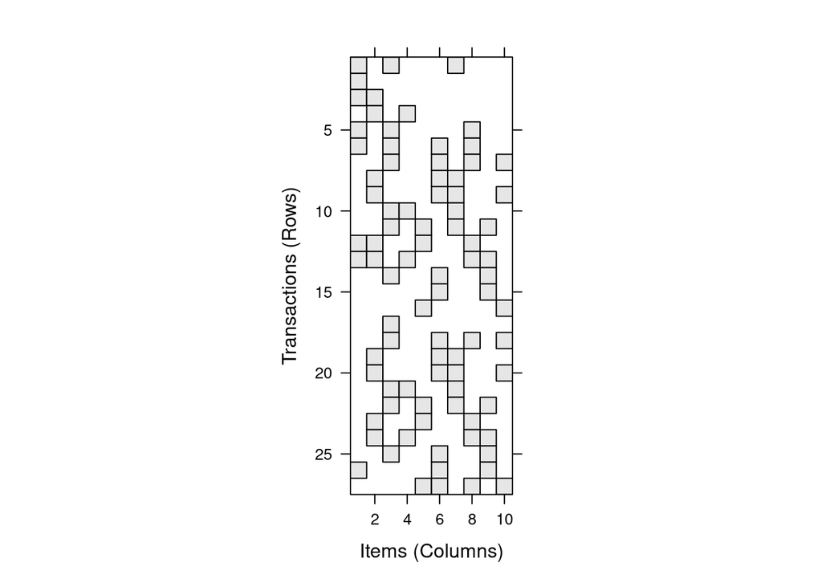

```r
image(dados_apriori)
```

```r
unique(itens$descrição)
```

```
##  [1] "banana prata"     "banana caturra"   "limao Taiti"      "limão siciliano"
##  [5] "coca"             "coca light"       "coca lemon light" "ariel total"
##  [9] "omo progress"     "omo collors"
```

```r
support.all = apriori(dados_apriori,
                      parameter =list(supp =0.2,
                                      target="frequent itemsets"
                                      )
                      )
```

```
## Apriori
##
## Parameter specification:
##  confidence minval smax arem  aval originalSupport maxtime support minlen
##          NA    0.1    1 none FALSE            TRUE       5     0.2      1
##  maxlen            target  ext
##      10 frequent itemsets TRUE
##
## Algorithmic control:
##  filter tree heap memopt load sort verbose
##     0.1 TRUE TRUE  FALSE TRUE    2    TRUE
##
## Absolute minimum support count: 5
##
## set item appearances ...[0 item(s)] done [0.00s].
## set transactions ...[10 item(s), 27 transaction(s)] done [0.00s].
## sorting and recoding items ... [9 item(s)] done [0.00s].
## creating transaction tree ... done [0.00s].
## checking subsets of size 1 2 done [0.00s].
## sorting transactions ... done [0.00s].
## writing ... [9 set(s)] done [0.00s].
## creating S4 object  ... done [0.00s].
```

```r
inspect(sort(support.all, by="count"))
```

```
##     items              support   count
## [1] {banana prata}     0.4444444 12
## [2] {coca light}       0.4444444 12
## [3] {banana caturra}   0.3703704 10
## [4] {limão siciliano}  0.3333333  9
## [5] {limao Taiti}      0.3333333  9
## [6] {ariel total}      0.2962963  8
## [7] {omo collors}      0.2962963  8
## [8] {coca lemon light} 0.2222222  6
## [9] {omo progress}     0.2222222  6
```

Os itens mais frequentemente comprados são banana prata, coca light e banana caturra.

```r
regras.all = apriori(dados_apriori,
                      parameter =list(conf = 0.4,
                                      target="rules",
                                      minlen=2)
                      )
```

```
## Apriori
##
## Parameter specification:
##  confidence minval smax arem  aval originalSupport maxtime support minlen
##         0.4    0.1    1 none FALSE            TRUE       5     0.1      2
##  maxlen target  ext
##      10  rules TRUE
##
## Algorithmic control:
##  filter tree heap memopt load sort verbose
##     0.1 TRUE TRUE  FALSE TRUE    2    TRUE
##
## Absolute minimum support count: 2
##
## set item appearances ...[0 item(s)] done [0.00s].
## set transactions ...[10 item(s), 27 transaction(s)] done [0.00s].
## sorting and recoding items ... [10 item(s)] done [0.00s].
## creating transaction tree ... done [0.00s].
## checking subsets of size 1 2 3 done [0.00s].
## writing ... [30 rule(s)] done [0.00s].
## creating S4 object  ... done [0.00s].
```

```r
inspect(sort(regras.all, by=c("support","confidence")))
```

```
##      lhs                                  rhs               support
## [1]  {omo progress}                    => {coca light}      0.1851852
## [2]  {limão siciliano}                 => {banana prata}    0.1851852
## [3]  {coca light}                      => {omo progress}    0.1851852
## [4]  {banana prata}                    => {limão siciliano} 0.1851852
## [5]  {banana prata}                    => {coca light}      0.1851852
## [6]  {coca light}                      => {banana prata}    0.1851852
## [7]  {banana caturra, limão siciliano} => {coca light}      0.1481481
## [8]  {coca light, limão siciliano}     => {banana caturra}  0.1481481
## [9]  {banana caturra, coca light}      => {limão siciliano} 0.1481481
## [10] {ariel total}                     => {limao Taiti}     0.1481481
## [11] {omo collors}                     => {banana prata}    0.1481481
## [12] {omo collors}                     => {coca light}      0.1481481
## [13] {limao Taiti}                     => {ariel total}     0.1481481
## [14] {limão siciliano}                 => {banana caturra}  0.1481481
```

[output cut: 47 more lines]

```r
regras_redundantes = is.redundant(regras.all)

regras = regras.all[!regras_redundantes]

inspect(sort(regras, by="lift"))
```

```
##      lhs                                  rhs               support
## [1]  {coca light, limao Taiti}         => {omo progress}    0.1111111
## [2]  {banana caturra, coca light}      => {limão siciliano} 0.1481481
## [3]  {coca light, limão siciliano}     => {banana caturra}  0.1481481
## [4]  {limao Taiti, omo progress}       => {coca light}      0.1111111
## [5]  {banana caturra, limão siciliano} => {coca light}      0.1481481
## [6]  {omo progress}                    => {coca light}      0.1851852
## [7]  {coca light}                      => {omo progress}    0.1851852
## [8]  {coca light, omo progress}        => {limao Taiti}     0.1111111
## [9]  {banana prata, coca light}        => {limao Taiti}     0.1111111
## [10] {banana prata, limao Taiti}       => {coca light}      0.1111111
## [11] {coca light, limao Taiti}         => {banana prata}    0.1111111
## [12] {coca}                            => {banana caturra}  0.1111111
## [13] {coca lemon light}                => {limao Taiti}     0.1111111
## [14] {omo progress}                    => {limao Taiti}     0.1111111
```

[output cut: 47 more lines]

**Observações:**